# Composition Analysis of Heritage of the Printed Book dated 2026-03-30

# Overall summary

9,258,390 records and 477,884,696 attribute values in total. Constituent files:

- data/hpb/hpb.parquet (2.3GB)

## Temporal overview

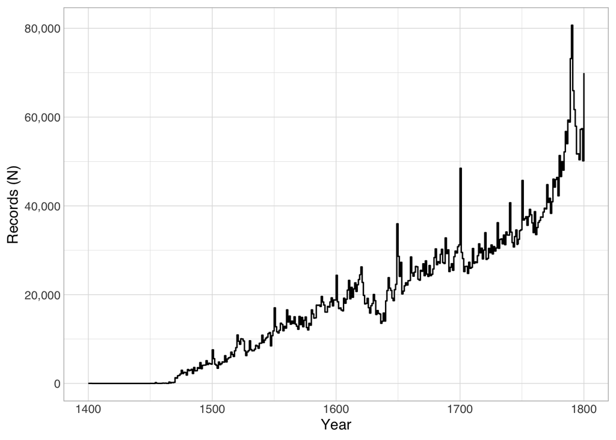

110,088 records do not have easily parseable dates between the years 1400 and 1800.

## Language overview

| [] | Records (N) | Proportion (%) |
| --- | --- | --- |
| lat (Latin) | 2464645 | 0.25403439471788 |
| fre (French) | 1720571 | 0.177341650645077 |
| ger (German) | 1576263 | 0.162467623986898 |
| und (Undetermined) | 945990 | 0.0975045075697177 |
| eng (English) | 792108 | 0.0816436753898392 |
| ita (Italian) | 684891 | 0.0705926697892489 |
| NA | 508570 | 0.0524190186098493 |
| dut (Dutch; Flemish) | 319628 | 0.0329445033726506 |
| spa (Spanish; Castilian) | 166739 | 0.0171860210865518 |
| grc (Greek, Ancient (to 1453)) | 96384 | 0.00993443319443089 |

[output cut: 642 more lines]

# Field code usage overview

In total, 110 distinct fields are used.

Legend for the table below:

- `records`: how many records have at least one of this field
- `r_p`: the above as a percentage of all records
- `n`: the total number of appearances of this field
- `vals_per_rec`: calculated from the above, the mean number of appearances of this field per record
- `recs_with_mult_vals`: the number of records that have more than one repetition of this field

| field_code | field_description | records | r_p | n | vals_per_rec | recs_with_mult_vals |
| --- | --- | --- | --- | --- | --- | --- |
| <a name="001A" href="https://swbtools.bsz-bw.de/cgi-bin/k10plushelp.pl?cmd=kat&val=0200">001A</a> | K10: Kennung und Datum der Ersterfassung\|GCC: Source and date of creation | 9258390 | 1 | 9258390 | 1 | 0 |
| <a name="001B" href="https://swbtools.bsz-bw.de/cgi-bin/k10plushelp.pl?cmd=kat&val=0210">001B</a> | K10: Kennung und Datum der letzten Änderung\|GCC: Source and date of the last transaction | 9258390 | 1 | 18516780 | 2 | 9258390 |
| <a name="001D" href="https://swbtools.bsz-bw.de/cgi-bin/k10plushelp.pl?cmd=kat&val=0230">001D</a> | K10: Kennung und Datum der Statusänderung\|GCC: Source and date of owner | 9258390 | 1 | 9258390 | 1 | 0 |
| <a name="001U" href="https://swbtools.bsz-bw.de/cgi-bin/k10plushelp.pl?cmd=kat&val=000K">001U</a> | K10: Characterset\|GCC: Characterset | 9258390 | 1 | 9258390 | 1 | 0 |
| <a name="001X" href="https://swbtools.bsz-bw.de/cgi-bin/k10plushelp.pl?cmd=kat&val=000A">001X</a> | K10: Owner main record\|GCC: Owner main record | 9258390 | 1 | 9258390 | 1 | 0 |
| <a name="002@" href="https://swbtools.bsz-bw.de/cgi-bin/k10plushelp.pl?cmd=kat&val=0500">002@</a> | K10: Bibliografische Gattung und Status\|GCC: Bibliographic type and status | 9258383 | 0.99999924392902 | 9258391 | 1.00000086408177 | 8 |
| <a name="003@" href="https://swbtools.bsz-bw.de/cgi-bin/k10plushelp.pl?cmd=kat&val=0100">003@</a> | K10: Pica-Produktionsnummer\|GCC: Record Control Number (PPN) | 9258390 | 1 | 9258390 | 1 | 0 |
| <a name="003G" href="https://swbtools.bsz-bw.de/cgi-bin/k10plushelp.pl?cmd=kat&val=2096">003G</a> | K10: Partner-Dokument-ID (VFL) Feld in Bearbeitung! | 96080 | 0.0103776142504258 | 219882 | 2.28853039134055 | 96080 |
| <a name="003O" href="https://swbtools.bsz-bw.de/cgi-bin/k10plushelp.pl?cmd=kat&val=2097">003O</a> | K10: OCLC-Nummer\|GCC: Control Number of the linked record in remote database (s.a.WorldCat) | 3685399 | 0.398060461916165 | 6831790 | 1.85374500834238 | 1576322 |
| <a name="004A" href="https://swbtools.bsz-bw.de/cgi-bin/k10plushelp.pl?cmd=kat&val=2000">004A</a> | K10: ISBN\|GCC: ISBN, binding, price | 23865 | 0.00257766199090771 | 28993 | 1.21487534045674 | 5060 |

[output cut: 100 more lines]

# Field code usage overview by subfield

In total, 733 distinct field+subfield combinations are used.

Legend for the table below:

- `records`: how many records have at least one of this field+subfield
- `r_p`: the above as a percentage of all records
- `dist_vals`: the number of different values appearing in this field+subfield
- `e_vals`: at most seven random sample values of this field+subfield
- `n`: the total number of appearances of this field+subfield
- `vals_per_rec`: calculated from the above, the mean number of appearances of this field+subfield per record
- `recs_with_mult_vals`: the number of records that have more than one repetition of this field+subfield

| subfield_code | subfield_description | records | r_p | dist_vals | e_vals | n | vals_per_rec | recs_with_mult_vals |
| --- | --- | --- | --- | --- | --- | --- | --- | --- |
| [001A: K10: Kennung und Datum der Ersterfassung\|GCC: Source and date of creation](https://swbtools.bsz-bw.de/cgi-bin/k10plushelp.pl?cmd=kat&val=0200) |  |  |  |  |  |  |  |  |
| 001A$0 | K10: Kennung und Datum der Ersterfassung\|GCC: Source and date | 9,258,390 | 100% | 16,606 | 9831:11-09-10 (33)\|9831:13-06-78 (16)\|9831:09-06-95 (176)\|9831:22-06-98 (413)\|9831:24-11-90 (1)\|9831:02-06-88 (77)\|9831:24-01-15 (42) | 9,258,390 | 1 | 0 |
| [001B: K10: Kennung und Datum der letzten Änderung\|GCC: Source and date of the last transaction](https://swbtools.bsz-bw.de/cgi-bin/k10plushelp.pl?cmd=kat&val=0210) |  |  |  |  |  |  |  |  |
| 001B$0 | K10: Kennung und Datum\|GCC: Source and date | 9,258,390 | 100% | 40 | 0007:19-08-25 (1)\|0007:29-10-24 (1)\|9831:28-01-22 (160,478)\|9831:08-09-23 (1,291,353)\|1999:26-11-21 (211,557)\|1999:22-11-21 (1,158,649)\|0007:14-09-23 (1) | 9,258,390 | 1 | 0 |
| 001B$t | K10: Uhrzeit\|GCC: Timestamp | 9,258,390 | 100% | 86,373 | 06:11:25.000 (98)\|02:42:24.000 (69)\|12:36:35.000 (105)\|05:33:05.000 (37)\|12:21:43.000 (171)\|08:49:04.000 (47)\|03:02:08.000 (47) | 9,258,390 | 1 | 0 |
| [001D: K10: Kennung und Datum der Statusänderung\|GCC: Source and date of owner](https://swbtools.bsz-bw.de/cgi-bin/k10plushelp.pl?cmd=kat&val=0230) |  |  |  |  |  |  |  |  |
| 001D$0 | K10: Kennung und Datum\|GCC: Source and date | 9,258,390 | 100% | 24 | 9831:27-08-21 (10)\|9831:22-04-21 (109,733)\|9831:12-04-22 (35,319)\|9831:18-05-20 (584,697)\|9831:20-08-21 (26,044)\|9831:12-08-25 (2,599)\|9831:22-06-21 (50,390) | 9,258,390 | 1 | 0 |
| [001U: K10: Characterset\|GCC: Characterset](https://swbtools.bsz-bw.de/cgi-bin/k10plushelp.pl?cmd=kat&val=000K) |  |  |  |  |  |  |  |  |
| 001U$0 | K10: Unicode-Kennzeichen | 9,258,390 | 100% | 1 | utf8 (9,258,390) | 9,258,390 | 1 | 0 |
| [001X: K10: Owner main record\|GCC: Owner main record](https://swbtools.bsz-bw.de/cgi-bin/k10plushelp.pl?cmd=kat&val=000A) |  |  |  |  |  |  |  |  |
| 001X$0 | K10: Owner\|GCC: Owner | 9,258,390 | 100% | 1 | 0 (9,258,390) | 9,258,390 | 1 | 0 |
| [002@: K10: Bibliografische Gattung und Status\|GCC: Bibliographic type and status](https://swbtools.bsz-bw.de/cgi-bin/k10plushelp.pl?cmd=kat&val=0500) |  |  |  |  |  |  |  |  |
| 002@$0 | K10: Bibliografische Gattung und Status | 9,258,383 | 100% | 92 | Oax (35)\|AcX (3)\|Arn (135)\|Aaus (78,470)\|Ack (29)\|Acv (3,669)\|Aau (178,775) | 9,258,383 | 1 | 0 |
| 002@$b | NA | 8 | 0% | 2 | Retro; VD18Nach; VD18Nach (2)\|Retro Retro (6) | 8 | 1 | 0 |
| [003@: K10: Pica-Produktionsnummer\|GCC: Record Control Number (PPN)](https://swbtools.bsz-bw.de/cgi-bin/k10plushelp.pl?cmd=kat&val=0100) |  |  |  |  |  |  |  |  |
| 003@$0 | K10: Pica-Produktionsnummer\|GCC: Number | 9,258,390 | 100% | 9,258,390 | 06462191X (1)\|023172738 (1)\|035940379 (1)\|097608718 (1)\|068437382 (1)\|033074283 (1)\|045667144 (1) | 9,258,390 | 1 | 0 |
| [003G: K10: Partner-Dokument-ID (VFL) Feld in Bearbeitung!](https://swbtools.bsz-bw.de/cgi-bin/k10plushelp.pl?cmd=kat&val=2096) |  |  |  |  |  |  |  |  |
| 003G$0 | K10: Dokument-ID | 96,080 | 1.04% | 66,186 | vd16p4196 (4)\|vd16b9336 (3)\|vd16s4955 (1)\|vd16zv18345 (1)\|vd16d1323 (1)\|vd16b6275 (1)\|vd16w208 (3) | 109,941 | 1.14 | 13,461 |
| 003G$a | K10: Partnerverbund | 96,080 | 1.04% | 1 | cluster:vd16 (109,941) | 109,941 | 1.14 | 13,461 |
| [003O: K10: OCLC-Nummer\|GCC: Control Number of the linked record in remote database (s.a.WorldCat)](https://swbtools.bsz-bw.de/cgi-bin/k10plushelp.pl?cmd=kat&val=2097) |  |  |  |  |  |  |  |  |
| 003O$0 | K10: Identnummer\|GCC: Control Number | 3,685,399 | 39.81% | 3,761,474 | 257820453 (1)\|(OCoLC)257624184 (1)\|(OCoLC)882582031 (1)\|247264381 (1)\|832276468 (1)\|(OCoLC)906980526 (1)\|649368003 (1) | 3,973,137 | 1.08 | 287,698 |
| 003O$a | K10: Codierung für folgende ID\|GCC: Remote Source Id (s.a. OCoLC) | 1,573,015 | 16.99% | 275,993 | ocm02198110 (1)\|ocm33991219 (2)\|ocn701818334 (1)\|ocm54194662 (1)\|ocn702319492 (1)\|ocm04249852 (1)\|ocm47135960 (1) | 1,573,016 | 1 | 1 |
| 003O$v | K10: Datum | 1,285,637 | 13.89% | 3 | 2012-12 (1)\|2012-12-31 (1,285,635)\|2009-06-15 (1) | 1,285,637 | 1 | 0 |
| [004A: K10: ISBN\|GCC: ISBN, binding, price](https://swbtools.bsz-bw.de/cgi-bin/k10plushelp.pl?cmd=kat&val=2000) |  |  |  |  |  |  |  |  |
| 004A$0 | K10: ISBN\|GCC: ISBN (length 10) | 21,944 | 0.24% | 8,388 | 3-598-52503-6 (3)\|3-89131-275-X (1)\|3-628-75114-4 (1)\|3-628-41017-7 (1)\|3-628-37384-0 (1)\|3-628-64018-0 (1)\|3-598-52333-5 (2) | 22,105 | 1.01 | 133 |
| 004A$A | GCC: ISBN (length 13) | 1 | 0% | 1 | 0-524-09838-7 (1) | 1 | 1 | 0 |
| 004A$f | K10: Kommentar zur ISBN, Einbandart, Lieferbedingungen und/oder Preis\|GCC: Terms of availability/price | 6,865 | 0.07% | 381 | : DM 145, (zusammen mit den anderen Werken des Autors) (1)\| (vol.2) (2)\| : 29 EUR (br.) (1)\| : DM 119, (zusammen mit den anderen Werken des Autors) (40)\| : DM 56, (zusammen mit den anderen Werken … | 6,887 | 1 | 17 |
| [004D: K10: Formal falsche ISBN\|GCC: Erroneous ISBN](https://swbtools.bsz-bw.de/cgi-bin/k10plushelp.pl?cmd=kat&val=2009) |  |  |  |  |  |  |  |  |
| 004D$0 | K10: ISBN\|GCC: ISBN (length 10) | 147 | 0% | 152 | 3-628-61618-1 (1)\|3-628-48091-2 (2)\|5 CE 0378 (1)\|3628552427 (1)\|9780576033251 (1)\|3-628-63162-7 (1)\|3806705607 (1) | 184 | 1.25 | 36 |
| 004D$f | K10: Kommentar zur ISBN, Einbandart, Lieferbedingungen und/oder Preis\|GCC: Terms of availability/price | 11 | 0% | 10 | Sekundärausgabe (1)\| : DM 20, (zusammen mit den anderen Werken des Autors) (1)\| (alk. paper) (1)\| : CtY (1)\| : ár nélkül (fűzött) (1)\| (vol. 5) (1)\| (vol. 6-7) (1) | 11 | 1 | 0 |

[output cut: 813 more lines]